# Case Study: How Does a Bike-Share Navigate Speedy Success?

Marwan Ashraf

2023-02-09

# About Company

In 2016, Cyclistic launched a successful bike-share offering. Since then, the program has grown to a fleet of **5,824** bicycles that are geotracked and locked into a network of **692** stations across Chicago. The bikes can be unlocked from one station and returned to any other station in the system anytime.  
**Cyclistic** classifies it users into two categories:  
1. **Casual Riders**: Customer who purchase single ride or full-day passes.  
2. **Members**: Customer who purchase **annual membership**.

# Stakholders in the Scenario

**Lily Moreno**: The director of marketing and your manager. Moreno is responsible for the development of campaigns and initiatives to promote the bike-share program. These may include email, social media, and other channels.  
**Cyclistic marketing analytics team**: A team of data analysts who are responsible for collecting, analyzing, and reporting data that helps guide Cyclistic marketing strategy. You joined this team six months ago and have been busy learning about Cyclistic’s mission and business goals — as well as how you, as a junior data analyst, can help Cyclistic achieve them.  
**Cyclistic executive team**: The notoriously detail-oriented executive team will decide whether to approve the recommended marketing program.

# Busnies task

**Three questions will guide the future marketing program:**  
1. How do annual members and casual riders use Cyclistic bikes differently?  
2. Why would casual riders buy Cyclistic annual memberships?  
3. How can Cyclistic use digital media to influence casual riders to become members?  
**this analysis aims to answer the first question**:How do annual members and casual riders use Cyclistic bikes differently?

# Loading packages.

```r
library(tidyverse)
library(lubridate)
library(tidyr)
library(dplyr)
```

# Importing the dataset

For this project I will use Cyclistic historical data for 2022 trips [data](https://divvy-tripdata.s3.amazonaws.com/index.html)under this [license](https://www.divvybikes.com/data-license-agreement)

```r
tripdata_202201 <- read_csv("202201-divvy-tripdata.csv")
tripdata_202202 <- read_csv("202202-divvy-tripdata.csv")
tripdata_202203 <- read_csv("202203-divvy-tripdata.csv")
tripdata_202204 <- read_csv("202204-divvy-tripdata.csv")
tripdata_202205 <- read_csv("202205-divvy-tripdata.csv")
tripdata_202206 <- read_csv("202206-divvy-tripdata.csv")
tripdata_202207 <- read_csv("202207-divvy-tripdata.csv")
tripdata_202208 <- read_csv("202208-divvy-tripdata.csv")
tripdata_202209 <- read_csv("202209-divvy-tripdata.csv")
tripdata_202210 <- read_csv("202210-divvy-tripdata.csv")
tripdata_202211 <- read_csv("202211-divvy-tripdata.csv")
tripdata_202212 <- read_csv("202212-divvy-tripdata.csv")
```

# Combining all the dataframes in one dataframe

```r
total_tripdata_2022 <- rbind(tripdata_202201,tripdata_202202,
           tripdata_202203,tripdata_202204,
           tripdata_202205,tripdata_202206,
           tripdata_202207,tripdata_202208,
           tripdata_202209,tripdata_202210,
           tripdata_202211,tripdata_202212)
```

# Showing the data

```r
summary(total_tripdata_2022)
```

```
##    ride_id          rideable_type        started_at
##  Length:5667717     Length:5667717     Min.   :2022-01-01 00:00:05.00
##  Class :character   Class :character   1st Qu.:2022-05-28 19:21:05.00
##  Mode  :character   Mode  :character   Median :2022-07-22 15:03:59.00
##                                        Mean   :2022-07-20 07:21:18.74
##                                        3rd Qu.:2022-09-16 07:21:29.00
##                                        Max.   :2022-12-31 23:59:26.00
##
##     ended_at                      start_station_name start_station_id
##  Min.   :2022-01-01 00:01:48.00   Length:5667717     Length:5667717
##  1st Qu.:2022-05-28 19:43:07.00   Class :character   Class :character
##  Median :2022-07-22 15:24:44.00   Mode  :character   Mode  :character
##  Mean   :2022-07-20 07:40:45.33
##  3rd Qu.:2022-09-16 07:39:03.00
##  Max.   :2023-01-02 04:56:45.00
##
##  end_station_name   end_station_id       start_lat       start_lng
##  Length:5667717     Length:5667717     Min.   :41.64   Min.   :-87.84
##  Class :character   Class :character   1st Qu.:41.88   1st Qu.:-87.66
##  Mode  :character   Mode  :character   Median :41.90   Median :-87.64
##                                        Mean   :41.90   Mean   :-87.65
##                                        3rd Qu.:41.93   3rd Qu.:-87.63
##                                        Max.   :45.64   Max.   :-73.80
##
##     end_lat         end_lng       member_casual
##  Min.   : 0.00   Min.   :-88.14   Length:5667717
##  1st Qu.:41.88   1st Qu.:-87.66   Class :character
##  Median :41.90   Median :-87.64   Mode  :character
##  Mean   :41.90   Mean   :-87.65
##  3rd Qu.:41.93   3rd Qu.:-87.63
##  Max.   :42.37   Max.   :  0.00
##  NA's   :5858    NA's   :5858
```

# Data prepration

## Showing the data limtitaion

```r
nrow(total_tripdata_2022)
```

```
## [1] 5667717
```

```r
sum(is.na(total_tripdata_2022))
```

```
## [1] 3463328
```

There is a lot of missing values So I’m going to explore the data sets columns to find which columns has those missing values after some digging I have those columns have the missing values.

```r
sum(is.na(total_tripdata_2022$start_station_name))
```

```
## [1] 833064
```

```r
sum(is.na(total_tripdata_2022$start_station_id))
```

```
## [1] 833064
```

```r
sum(is.na(total_tripdata_2022$end_station_name))
```

```
## [1] 892742
```

```r
sum(is.na(total_tripdata_2022$end_station_id))
```

```
## [1] 892742
```

```r
sum(is.na(total_tripdata_2022$end_lat))
```

```
## [1] 5858
```

```r
sum(is.na(total_tripdata_2022$end_lng))
```

```
## [1] 5858
```

# Data Cleaning

I decided to exclude the rows with missing values from my analysis

```r
total_tripdata_2022 <- drop_na(total_tripdata_2022)
nrow(total_tripdata_2022)
```

```
## [1] 4369360
```

Also I have decided to add more columns to my data frame to help me in my analysis and those columns are Ride_length, month, day and hour.

```r
total_tripdata_2022$ride_length <-difftime(total_tripdata_2022$ended_at,total_tripdata_2022$started_at)
total_tripdata_2022$month <-format(as.Date(total_tripdata_2022$started_at),"%b")
total_tripdata_2022$day_of_week <- weekdays(total_tripdata_2022$started_at)
total_tripdata_2022$hours <-format(as.POSIXct(total_tripdata_2022$started_at),format= "%H")
```

Putting the day of the week and the month in the right order

```r
total_tripdata_2022$day_of_week <- ordered(total_tripdata_2022$day_of_week,
                                           levels=c("Sunday", "Monday", "Tuesday",
                                                     "Wednesday", "Thursday", "Friday", "Saturday"))
total_tripdata_2022$month <- ordered(total_tripdata_2022$month,
                                           levels=c("Jan","Feb","Mar",
                                                     "Apr","May","Jun",
                                                     "Jul","Aug","Sep",
                                                     "Oct","Nov","Dec"))
```

The dataframe includes a few hundred entries when bikes were taken out of docks and checked for quality by Divvy or ride_length was negative So we will going toe create a new dataframe that exclude those values.

```r
tripdata_2022 <-  total_tripdata_2022[!(total_tripdata_2022$start_station_name == "HQ QR" | total_tripdata_2022$ride_length<0),]
```

# Analysis

**Descriptive analysis on the ride length**

```r
mean(tripdata_2022$ride_length) # the mean of the ride
```

```
## Time difference of 1025.75 secs
```

```r
median(tripdata_2022$ride_length) # the median of the rides
```

```
## Time difference of 636 secs
```

```r
max(tripdata_2022$ride_length) # maximum ride length
```

```
## Time difference of 2061244 secs
```

```r
min(tripdata_2022$ride_length) # minimum ride length
```

```
## Time difference of 0 secs
```

**Compare members and casual users**

```r
aggregate(tripdata_2022$ride_length ~ tripdata_2022$member_casual, FUN = mean)
```

```
##   tripdata_2022$member_casual tripdata_2022$ride_length
## 1                      casual             1439.586 secs
## 2                      member              747.104 secs
```

```r
aggregate(tripdata_2022$ride_length ~ tripdata_2022$member_casual, FUN = median)
```

```
##   tripdata_2022$member_casual tripdata_2022$ride_length
## 1                      casual                  831 secs
## 2                      member                  539 secs
```

```r
aggregate(tripdata_2022$ride_length ~ tripdata_2022$member_casual, FUN = max)
```

```
##   tripdata_2022$member_casual tripdata_2022$ride_length
## 1                      casual              2061244 secs
## 2                      member                89594 secs
```

```r
aggregate(tripdata_2022$ride_length ~ tripdata_2022$member_casual, FUN = min)
```

```
##   tripdata_2022$member_casual tripdata_2022$ride_length
## 1                      casual                    0 secs
## 2                      member                    0 secs
```

**See the average ride time by each day for members vs casual users**

```r
aggregate(tripdata_2022$ride_length ~ tripdata_2022$member_casual + tripdata_2022$day_of_week, FUN = mean)
```

```
##    tripdata_2022$member_casual tripdata_2022$day_of_week
## 1                       casual                    Sunday
## 2                       member                    Sunday
## 3                       casual                    Monday
## 4                       member                    Monday
## 5                       casual                   Tuesday
## 6                       member                   Tuesday
## 7                       casual                 Wednesday
## 8                       member                 Wednesday
## 9                       casual                  Thursday
## 10                      member                  Thursday
## 11                      casual                    Friday
## 12                      member                    Friday
## 13                      casual                  Saturday
## 14                      member                  Saturday
##    tripdata_2022$ride_length
## 1             1633.6491 secs
## 2              831.0463 secs
## 3             1490.0468 secs
## 4              721.9727 secs
## 5             1286.5190 secs
## 6              707.4686 secs
## 7             1243.0783 secs
## 8              710.8143 secs
## 9             1284.2069 secs
## 10             721.9113 secs
## 11            1341.4274 secs
## 12             733.6164 secs
## 13            1605.9639 secs
## 14             838.8955 secs
```

**Analyze ridership data by type and weekday**

```r
tripdata_2022 %>%
  mutate(weekday = wday(started_at,label = TRUE)) %>%
    group_by(member_casual,weekday) %>%
  summarize(number_of_rides = n(),
            average_duration = mean(ride_length)) %>%
  arrange(member_casual, weekday)
```

```
## # A tibble: 14 × 4
## # Groups:   member_casual [2]
##    member_casual weekday number_of_rides average_duration
##    <chr>         <ord>             <int> <drtn>
##  1 casual        Sun              301296 1633.6491 secs
##  2 casual        Mon              210757 1490.0468 secs
##  3 casual        Tue              196380 1286.5190 secs
##  4 casual        Wed              203576 1243.0783 secs
##  5 casual        Thu              230005 1284.2069 secs
##  6 casual        Fri              248796 1341.4274 secs
##  7 casual        Sat              367340 1605.9639 secs
##  8 member        Sun              297722  831.0463 secs
##  9 member        Mon              375168  721.9727 secs
## 10 member        Tue              411244  707.4686 secs
## 11 member        Wed              412794  710.8143 secs
## 12 member        Thu              415887  721.9113 secs
## 13 member        Fri              360053  733.6164 secs
## 14 member        Sat              338273  838.8955 secs
```

**Showing the maximum ride length at every hour in the day for each user category**

```r
aggregate(tripdata_2022$ride_length ~ tripdata_2022$member_casual + tripdata_2022$hours, FUN = max)
```

```
##    tripdata_2022$member_casual tripdata_2022$hours tripdata_2022$ride_length
## 1                       casual                  00                84509 secs
## 2                       member                  00                86625 secs
## 3                       casual                  01              1756266 secs
## 4                       member                  01                69947 secs
## 5                       casual                  02               113657 secs
## 6                       member                  02                59351 secs
## 7                       casual                  03               207746 secs
## 8                       member                  03                33952 secs
## 9                       casual                  04                87410 secs
## 10                      member                  04                50054 secs
## 11                      casual                  05                78160 secs
## 12                      member                  05                86721 secs
## 13                      casual                  06               835693 secs
## 14                      member                  06                54532 secs
```

[output cut: 34 more lines]

# Visualizations

**Visualize the relation between customers type and readable type using ggplot** **to see each customer bike preferences and also to know which ride type is used more often**

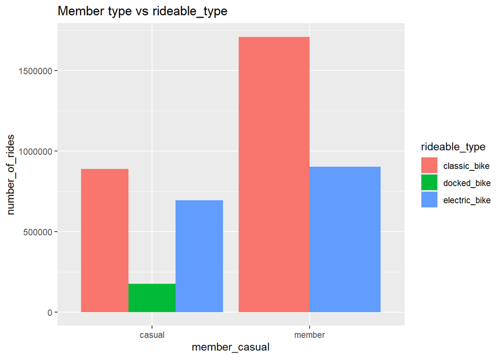

```r
tripdata_2022 %>%
  group_by(member_casual,rideable_type) %>%
  summarize(number_of_rides=n()) %>%
  ggplot(aes(x=member_casual,y=number_of_rides,fill=rideable_type))+
  geom_col(position = "dodge")+ggtitle("Member type vs rideable_type")
```

**Visualizing the number of rides each customer type made every month**

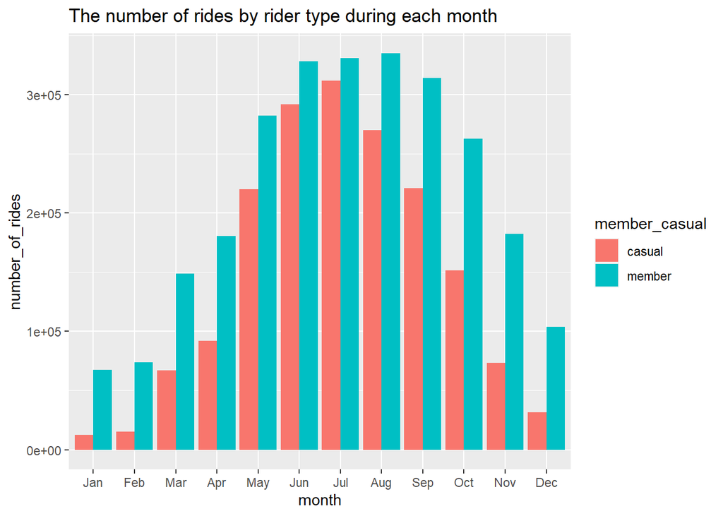

```r
tripdata_2022 %>%
  group_by(member_casual, month) %>%
  summarise(number_of_rides = n()
            ,average_duration = mean(ride_length)) %>%
  arrange(member_casual, month)  %>%
  ggplot(aes(x = month, y = number_of_rides, fill = member_casual)) +
  geom_col(position = "dodge") +ggtitle("The number of rides by rider type during each month")
```

**Visualizing the number of rides each customer type made every day**

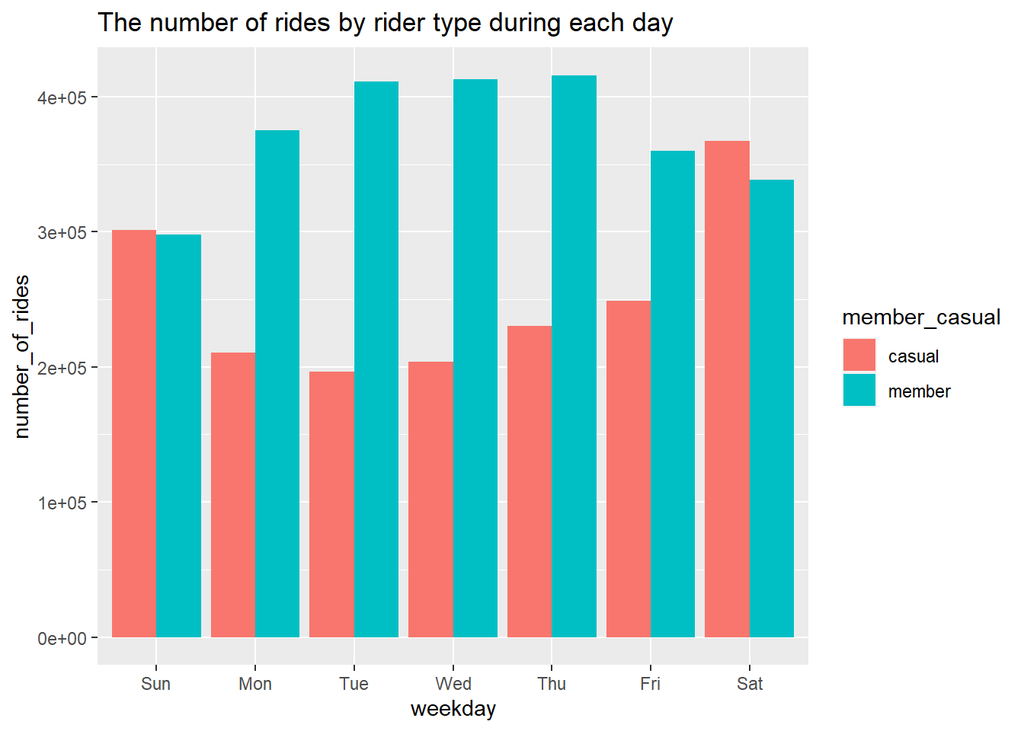

```r
tripdata_2022 %>%
  mutate(weekday = wday(started_at, label = TRUE)) %>%
  group_by(member_casual, weekday) %>%
  summarise(number_of_rides = n()
            ,average_duration = mean(ride_length)) %>%
  arrange(member_casual, weekday)  %>%
  ggplot(aes(x = weekday, y = number_of_rides, fill = member_casual)) +
  geom_col(position = "dodge")+ggtitle("The number of rides by rider type during each day")
```

**Visualizing the number of rides each customer type made at every hour of the day**

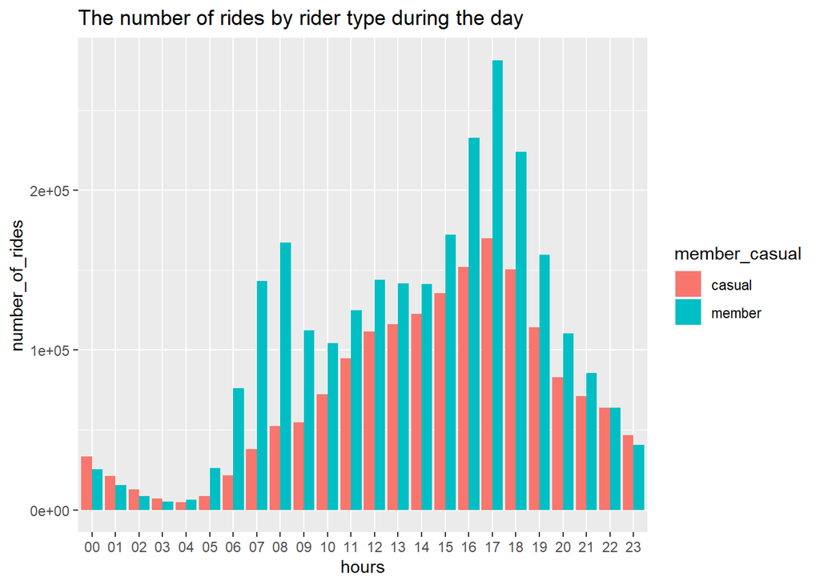

```r
tripdata_2022 %>%
  group_by(member_casual,hours) %>%
  summarise(number_of_rides = n(),
            average_duration = mean(ride_length)) %>%
  ggplot(aes(x = hours, y = number_of_rides, fill = member_casual))+
  geom_col(position = "dodge")+ggtitle("The number of rides by rider type during the day")
```

**Visualizing the average ride length of the customers types each month,day and hour**

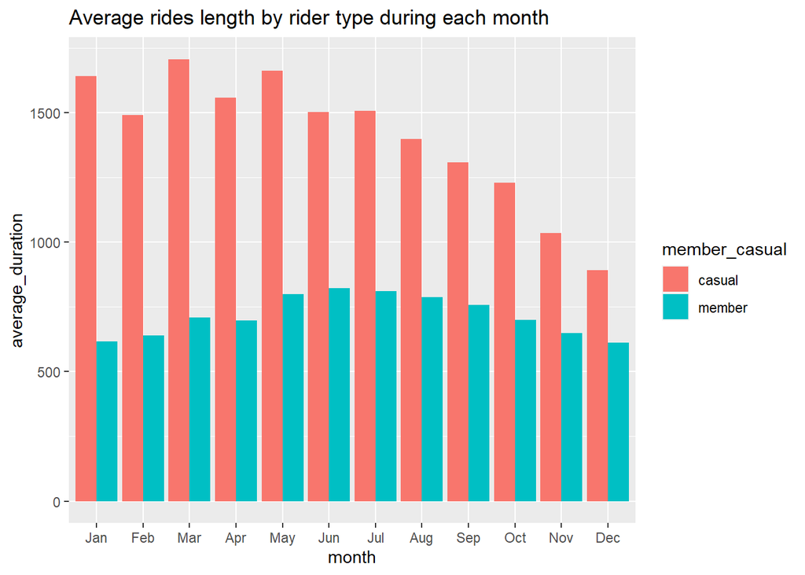

```r
tripdata_2022 %>%
  group_by(member_casual, month) %>%
  summarise(number_of_rides = n()
            ,average_duration = mean(ride_length)) %>%
  arrange(member_casual, month)  %>%
  ggplot(aes(x = month, y = average_duration, fill = member_casual)) +
  geom_col(position = "dodge") +ggtitle("Average rides length by rider type during each month")
```